# Practical Machine Learning - Course Project

Andrey Boytsov

November 2015

## 1. Problem Formulation

The task is to build a predictor that distinguish different types of human excercise using measurements from wearable sensors. A labeled dataset is provided.

The rest of the paper is structured as follows:

- Section 2 describes dataset, data acquisition and cleaning. It also describes the strategy for train/validation/test split and cross-validation strategy.
- Section 3 contains evaluation of several models using cross-validation
- Section 4 describes final model selection and contains out-of-sample error estimation
- Section 5 summarizes and concludes the report.

Setting the seed for reproduction purposes:

```r
set.seed(16121984)
```

## 2. Data Acquisition and Cleaning

CSV file for the task was loaded at the following time: Sat Nov 14 12:24:42 2015 The data are loaded from CSV file in a following manner:

```r
download.file(url = "https://d396qusza40orc.cloudfront.net/predmachlearn/pml-training.csv",
              destfile="pml-training.csv")
xLabeled <- read.csv("pml-training.csv")
```

The labeled data contain 19622 labeled examples. The number of columns is 160 (159 potential predictors and a class label).

The following variables should not participate in the training. They do not influence excercise pattern, keeping them in the model can lead only to slowdown and overfits.

- *raw_timestamp_part_1*, *raw_timestamp_part_2*, *cvtd_timestamp* - all timestamps.
- *X* - sequential number of raw.
- *new_window*, *num_window* - timeframes of different excercises.
- *user_name* - name of tester. Unless the trained model will be used for the same users only, the username should not be taken into account when learning training patterns.

```r
columnsToDrop <-c("raw_timestamp_part_1","raw_timestamp_part_2","cvtd_timestamp","X","user_name","new_window", "num_window");
xLabeled <- xLabeled[, !(colnames(xLabeled) %in% columnsToDrop)]
```

Quick look at the data shows that some columns contain NAs and empty values. Consider the percentage of NAs and empty values by columns:

```r
table(c(round(do.call("cbind",lapply(xLabeled, function(x) (sum(is.na(x) | x=="")) / length(x))), digits = 2)))
```

```
##
##    0 0.98
##   53  100
```

So, 53 columns do not contain any NAs/empty values at all, while 100 columns contain about 98% of them. The latter 100 columns need to be dropped, they hardly ever contain any information and can cause problems for learning algorithms.

Here we remove all columns that have over 95% of NA or empty values:

```r
cutoff_percentage <- 0.95
xLabeled <- xLabeled[, lapply(xLabeled, function(x) (sum(is.na(x) | x=="")) / length(x)) < cutoff_percentage]
```

The number of predictors is now 52. This is a relatively small number, it should not require any form of dimensionality reduction.

The number of examples for each class is distributed as follows:

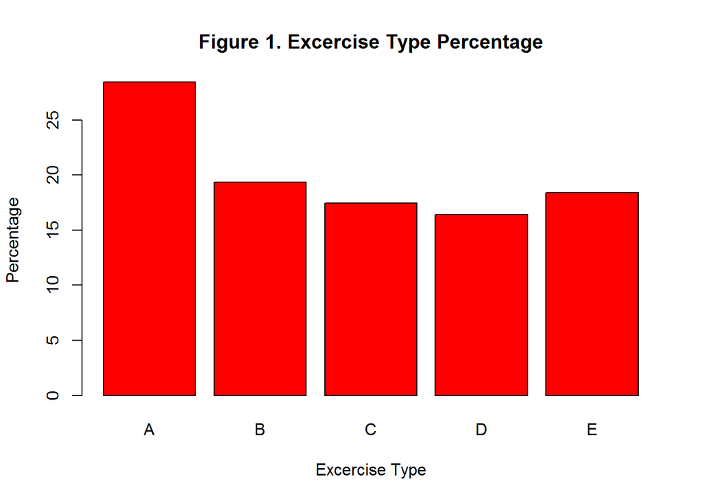

```r
barplot(table(xLabeled$classe)/length(xLabeled$classe)*100, xlab = "Excercise Type", ylab="Percentage", main = "Figure 1. Excercise Type Percentage", col = "red")
```

The classes are not skewed (the percentages of each class are relatively close), so accuracy is acceptable success metrics.

There are 19622 labeled examples available. Sample size is relatively large, and cross-validation is an explicit requirement for the task. Therefore, we can use the following protocol:

- 80% of data will be used for training and model selection. We will use K-fold cross validation on this data in order to pick prediction function and compare different predictors. We choose K=4 in order to have “classic” 60/20/20 training/testing/validation split on every cross-validation step.
- 20% of data are assigned to the test set. Selected model will be run only once on that set in order to estimate out-of-sample error. This test set will not be used in exploration, trainning and model selection in any way.

```r
dataPartitionTrain <- createDataPartition(xLabeled$classe, p = 0.8, list = F)
xTrain <- xLabeled[dataPartitionTrain,]
xTest <- xLabeled[-dataPartitionTrain,]
crossVal4Fold <- trainControl(method = "cv", number = 4)
```

The data have too many dimensions for straightforward visualization. However, plotting first 2 PCA components can give an idea about the structure of the data.

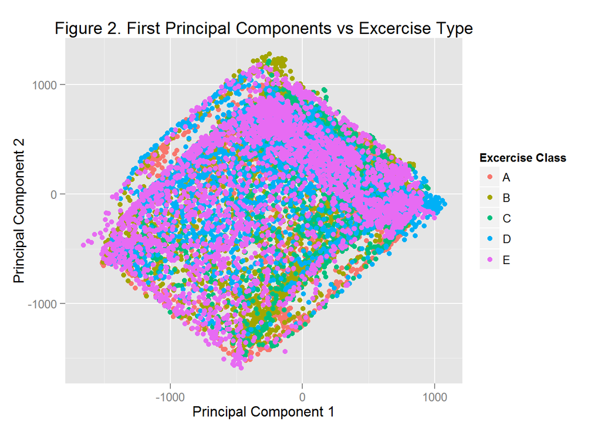

```r
prCompTrain <- prcomp(xTrain[,-53])
qplot(prCompTrain$x[,1], prCompTrain$x[,2], col = xTrain$classe, xlab = "Principal Component 1", ylab = "Principal Component 2", main = "Figure 2. First Principal Components vs Excercise Type") + guides(color=guide_legend(title="Excercise Class"))
```

There are no visible clusters corresponding to excercise. It gives a hint that problem is highly nonlinear.

Now the data are ready for applying machine learning algorithms.

## 3. Model Selection

In the upcoming sections we are going to evaluate several models and use test set accuracy for model selection.

### 3.1. Naive Bayesian Model

Naive Bayesian model relies on the assumption that distributions of predictor variables are independent given the class. For excercising this assumption is very likely to be inaccurate - within the same excercise movement of different parts of the body should have a lot of dependencies. Still Naive Bayesian approach can be used as a benchmark to compare with other models.

```r
# Using our own tuning grid, or training time becomes unmanageable
# Due to the numbers of examples it is quite clear that Laplace smoothing is not necessary
nbModel <- train(classe ~ ., data = xTrain, method = "nb", trControl = crossVal4Fold, tuneGrid=data.frame(fL=0, usekernel=F))
```

For this and subsequent models we are going to use average cross-validation test set accuracy i.e. average accuracy on hold-out 1/4 of data used for testing at each cross-validation fold. This is a standard metrics of cross-validation performance. **This metrics will be used for model selection.**

### 3.2. Linear Discriminant Analysis

Linear discriminant analysis (LDA) can be applied to that problem. However, LDA has an assumption that measurements for each excercise are normally distributed around some center. It is not realistic assumption, therefore, LDA is unlikely to produce good results.

```r
ldaModel <- train(classe ~ ., data = xTrain, method = "lda", trControl = crossVal4Fold)
```

Average CV testing set accuracy: 70.26%

The accuracy is still not high.

### 3.3. Decision Trees

Decision tree is practically very efficient method, although somewhat prone to overfitting. Instead of “rpart” implementation, proposed by the course, we are going to use more fast and robust J48 algorithm for decision tree construction.

```r
decTreeModel <- train(classe~., data = xTrain, method = "J48", trControl = crossVal4Fold)
```

Average CV testing set accuracy: 95.37%

Decision trees show much better accuracy than previously considered model.

### 3.4. Random Forests

Random forests are one of the most widely used models in practice. They are robust and definitely worth trying in this scenario.

```r
# Caret's automated adjustment for random forests will take many hours.
# We are doing our own training/test/validation manually. We do not use caret built-in training control and tuning
# Otherwise time to build random forest becomes unmanageable
randomForestModel <- train(classe ~ ., data = xTrain, method = "rf", trControl = crossVal4Fold, tuneGrid=data.frame(mtry=10))
```

Average CV testing set accuracy: 99.42%

Random forests show the best accuracy by far among the previously tested models.

### 3.4. Boosting

Boosting is a very popular and practical approach for combining the prediction methods. It is definitely worth trying for pretty much any task. Decision trees are frequent targets for boosting, and they produced one of the highest accuracy measurements for this task. There are many types of models that can be boosted, here we will just use decision trees as an example.

```r
lrBoostModel <- train(classe ~ ., data = xTrain, method = "gbm", trControl = crossVal4Fold, verbose = F)
```

Average CV testing set accuracy: 96.08%

The accuracy is very good. However, it is lower than for random forests.

## 4. Model Selection

Random forests provided highest accuracy averaged over cross-validation test sets. Therefore, random forests were chosen as a final model. Out-of-sample error can be estimated using the 20% test set, set aside initially from the dataset.

```r
finalEstimation <- confusionMatrix(predict(randomForestModel, xTest), xTest$classe)
finalAccuracy  <- finalEstimation$overall["Accuracy"]
finalAccuracyLower95  <- finalEstimation$overall["AccuracyLower"]
finalAccuracyHigher95  <- finalEstimation$overall["AccuracyUpper"]
outOfSampleErroEstimation <- 1 - finalAccuracy
outOfSampleHigher95 <- 1 - finalAccuracyLower95
outOfSampleLower95 <- 1 - finalAccuracyHigher95
```

Test set accuracy: 99.57% with 95% confidence intervals being [99.31,99.75] %. Therefore, out-of-sample error can be estimated as 1-accuracy = 0.43% with 95% confidence intervals being [0.25,0.69] %

The accuracy is about as high as cross-validation hold-out set accuracy (used for model selection). Therefore, there is no reason to suspect overfit.

Model information can be summarized as follows: - The model was built using 52 predictor variables. Cross-validation on 80% of the data was used for training and model selection. - The final model is a random forest model, built with 500 trees and 10 predictors sampled for splitting at each node. - The final model has 99.57% accuracy on the test set, and its performance can also be visualized using the following confusion matrix:

```r
table(predict(randomForestModel, xTest), xTest$classe)
```

```
##
##        A    B    C    D    E
##   A 1115    1    0    0    0
##   B    1  758    8    0    0
##   C    0    0  676    6    0
##   D    0    0    0  637    1
##   E    0    0    0    0  720
```

Prediction model is built and out-of-sample error is estimated. It completes the solution of the problem.

# 5. Summary